# Supplementary Information 3 - Global annual average landings of sharks and rays (Sharks MOU Annex-I listed, Non-listed and Uncertain) reported to FAO (2015-2019)

$~$

$~$

Each FAO area tab has two plots and a table representing the total landings of:

- shark and ray species listed under Annex 1 of Sharks MOU (Shars MOU)
- shark and ray species that are not listed under Annex 1 of Sharks MOU (Non Sharks MOU).
- the total landings that may contain listed and non-listed species (Uncertain)

Within each table, the contribution of each broad species category to the total number of reported uncertain landings is displayed after the “Uncertain” column. The numbers displayed at the last column of the table represent the yearly average of all shark and ray species reported as landed (Sharks MOU, Non Sharks MOU and Uncertain).

The first plot includes the top three nations reporting the highest landings, as can be seen in Figure 3 of the meeting document. The second plot represents a close up of the landings reported from the remaining nations as it is seen at the fourth bar within the plots presented in Figure 3. Note the scale between the two plots is different.

Colour of nations within plots indicate Sharks MOU and CMS Status: (Dark blue) Sharks MOU Signatory and CMS Party; (light blue) Sharks MOU Signatory only; (green) CMS Party only; (grey) range state. Note that not all colours may be present in any given plot.

$~$

# By FAO Area (Choose a tab to display)

$~$

$~$

## Area 21 - Atlantic, Northwest

$~$

$~$

Area 21 - Atlantic, Northwest

$~$

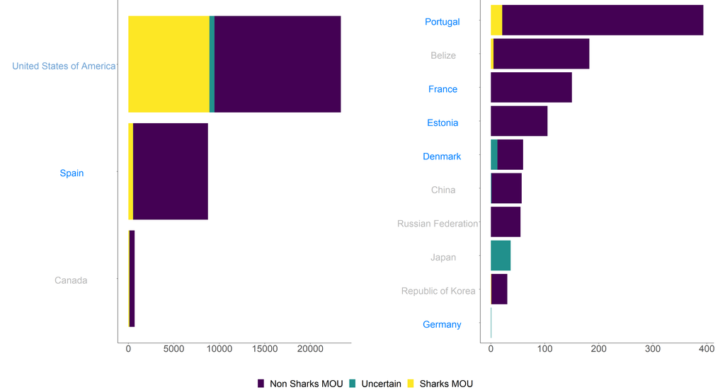

Area 21

| Country | Sharks MOU Status | CMS Status | Sharks MOU | Non Sharks MOU | Uncertain | Dogfish sharks nei | Sharks, rays, skates, etc. nei | Yearly Average Total |
| --- | --- | --- | --- | --- | --- | --- | --- | --- |
| United States of America | MOU Signatory | Non-Party | 8914.80 | 13889.00 | 550.20 | 509.40 | 40.80 | 23354.00 |
| Spain | MOU Signatory | Party | 516.75 | 8234.12 | 9.20 | 9.20 | - | 8760.07 |
| Canada | Range State | Non-Party | 118.20 | 554.20 | 13.80 | - | 13.80 | 686.20 |
| Portugal | MOU Signatory | Party | 21.00 | 372.60 | - | - | - | 393.60 |
| Belize | Range State | Non-Party | 4.80 | 177.80 | - | - | - | 182.60 |
| France | MOU Signatory | Party | - | 150.20 | - | - | - | 150.20 |
| Estonia | MOU Signatory | Party | - | 105.00 | - | - | - | 105.00 |
| Denmark | MOU Signatory | Party | 0.08 | 47.63 | 12.00 | 12.00 | - | 59.71 |
| China | Range State | Non-Party | - | 55.80 | 1.20 | - | 1.20 | 57.00 |
| Russian Federation | Range State | Non-Party | - | 55.00 | - | - | - | 55.00 |
| Japan | Range State | Non-Party | - | - | 36.60 | - | 36.60 | 36.60 |
| Republic of Korea | Range State | Non-Party | 0.81 | 29.58 | - | - | - | 30.39 |
| Germany | MOU Signatory | Party | - | - | 1.00 | 1.00 | - | 1.00 |

## Area 27 - Atlantic, Northeast

$~$

$~$

Area 27 - Atlantic, Northeast

$~$

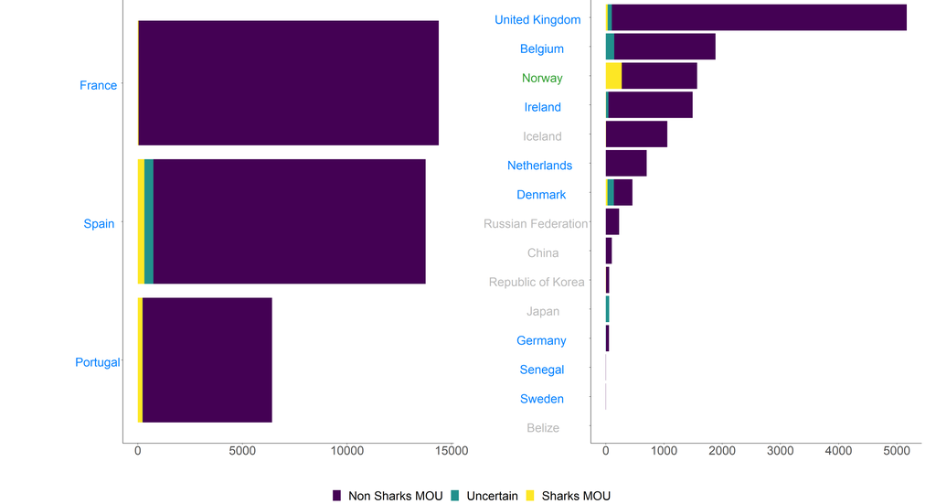

Area 27

| Country | Sharks MOU Status | CMS Status | Sharks MOU | Non Sharks MOU | Uncertain | Dogfish sharks nei | Dogfish sharks, etc. nei | Dogfishes and hounds nei | Dogfishes nei | Hammerhead sharks nei | Rays, stingrays, mantas nei | Requiem sharks nei | Sharks, rays, skates, etc. nei | Various sharks nei | Yearly Average Total |
| --- | --- | --- | --- | --- | --- | --- | --- | --- | --- | --- | --- | --- | --- | --- | --- |
| France | MOU Signatory | Party | 36.80 | 14342.20 | 4.20 | 3.20 | - | - | - | - | - | - | 1.00 | - | 14383.20 |
| Spain | MOU Signatory | Party | 317.67 | 13015.13 | 429.31 | 4.93 | 0.02 | - | - | 0.01 | 4.72 | 0.34 | - | 419.29 | 13762.11 |
| Portugal | MOU Signatory | Party | 221.40 | 6175.20 | 17.80 | - | - | 17.20 | - | - | - | - | 0.60 | - | 6414.40 |
| United Kingdom | MOU Signatory | Party | 34.40 | 5066.40 | 68.60 | 11.40 | - | 57.00 | - | - | - | - | - | 0.20 | 5169.40 |
| Belgium | MOU Signatory | Party | - | 1739.40 | 145.00 | - | - | 138.40 | - | - | - | - | - | 6.60 | 1884.40 |
| Norway | Range State | Party | 274.20 | 1295.60 | - | - | - | - | - | - | - | - | - | - | 1569.80 |
| Ireland | MOU Signatory | Party | 3.78 | 1445.70 | 41.66 | 21.88 | - | - | 4.30 | - | 4.18 | - | - | 11.30 | 1491.15 |
| Iceland | Range State | Non-Party | 4.20 | 1052.20 | - | - | - | - | - | - | - | - | - | - | 1056.40 |
| Netherlands | MOU Signatory | Party | 0.80 | 701.60 | - | - | - | - | - | - | - | - | - | - | 702.40 |
| Denmark | MOU Signatory | Party | 30.22 | 319.97 | 108.47 | 108.47 | - | - | - | - | - | - | - | - | 458.66 |
| Russian Federation | Range State | Non-Party | - | 227.80 | - | - | - | - | - | - | - | - | - | - | 227.80 |
| China | Range State | Non-Party | - | 102.60 | - | - | - | - | - | - | - | - | - | - | 102.60 |
| Republic of Korea | Range State | Non-Party | 2.35 | 56.78 | - | - | - | - | - | - | - | - | - | - | 59.13 |
| Japan | Range State | Non-Party | - | - | 57.20 | - | - | - | - | - | - | - | 57.20 | - | 57.20 |
| Germany | MOU Signatory | Party | 0.40 | 53.20 | 3.00 | 3.00 | - | - | - | - | - | - | - | - | 56.60 |
| Senegal | MOU Signatory | Party | - | 4.26 | - | - | - | - | - | - | - | - | - | - | 4.26 |
| Sweden | MOU Signatory | Party | 0.20 | 2.00 | 0.20 | - | - | - | - | - | - | - | 0.20 | - | 2.40 |
| Belize | Range State | Non-Party | 0.20 | 1.60 | - | - | - | - | - | - | - | - | - | - | 1.80 |

## Area 31 - Atlantic, Western Central

$~$

$~$

Area 31 - Atlantic, Western Central

$~$

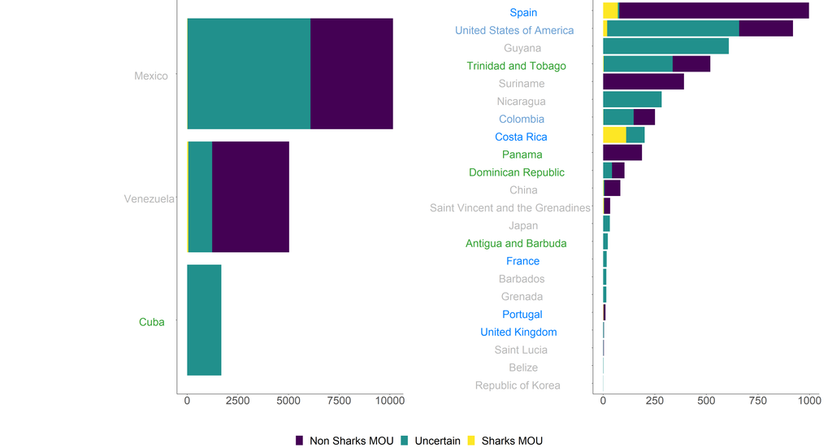

Area 31

| Country | Sharks MOU Status | CMS Status | Sharks MOU | Non Sharks MOU | Uncertain | Carcharhinus sharks nei | Hammerhead sharks nei | Hammerhead sharks, etc. nei | Rays, stingrays, mantas nei | Requiem sharks nei | Sharks, rays, skates, etc. nei | Yearly Average Total |
| --- | --- | --- | --- | --- | --- | --- | --- | --- | --- | --- | --- | --- |
| Mexico | Range State | Non-Party | 17.60 | 4069.40 | 6068.40 | - | - | 180.60 | 72.20 | 1293.60 | 4522.00 | 10155.40 |
| Venezuela | Range State | Non-Party | 51.40 | 3800.80 | 1176.80 | - | - | - | 607.60 | 177.20 | 392.00 | 5029.00 |
| Cuba | Range State | Party | - | - | 1685.82 | - | - | - | 1242.82 | - | 443.00 | 1685.82 |
| Spain | MOU Signatory | Party | 71.22 | 919.55 | 6.60 | - | - | - | - | - | 6.60 | 997.37 |
| United States of America | MOU Signatory | Non-Party | 19.00 | 260.53 | 640.20 | - | - | - | 12.40 | - | 627.80 | 919.73 |
| Guyana | Range State | Non-Party | - | - | 608.60 | - | - | - | - | - | 608.60 | 608.60 |
| Trinidad and Tobago | Range State | Party | 2.39 | 182.35 | 334.00 | - | - | 39.40 | - | - | 294.60 | 518.74 |
| Suriname | Range State | Non-Party | - | 391.80 | - | - | - | - | - | - | - | 391.80 |
| Nicaragua | Range State | Non-Party | - | - | 283.14 | - | - | - | 106.50 | - | 176.63 | 283.14 |
| Colombia | MOU Signatory | Non-Party | 0.71 | 103.00 | 147.10 | 2.27 | 0.03 | - | 53.20 | - | 91.60 | 250.81 |
| Costa Rica | MOU Signatory | Party | 111.20 | - | 89.60 | - | - | - | - | - | 89.60 | 200.80 |
| Panama | Range State | Party | - | 188.20 | - | - | - | - | - | - | - | 188.20 |
| Dominican Republic | Range State | Party | - | 60.80 | 42.60 | - | - | - | 42.60 | - | - | 103.40 |
| China | Range State | Non-Party | 2.40 | 77.00 | 3.80 | - | - | - | - | - | 3.80 | 83.20 |
| Saint Vincent and the Grenadines | Range State | Non-Party | 2.80 | 29.60 | 1.60 | - | - | - | - | 1.00 | 0.60 | 34.00 |
| Japan | Range State | Non-Party | - | - | 31.80 | - | - | - | - | - | 31.80 | 31.80 |
| Antigua and Barbuda | Range State | Party | - | - | 22.00 | - | - | - | - | - | 22.00 | 22.00 |
| France | MOU Signatory | Party | - | - | 16.80 | - | - | - | 12.80 | - | 4.00 | 16.80 |
| Barbados | Range State | Non-Party | - | - | 15.40 | - | - | - | - | - | 15.40 | 15.40 |
| Grenada | Range State | Non-Party | - | - | 15.00 | - | - | - | - | - | 15.00 | 15.00 |
| Portugal | MOU Signatory | Party | 1.00 | 9.80 | - | - | - | - | - | - | - | 10.80 |
| United Kingdom | MOU Signatory | Party | - | 1.40 | 2.60 | - | - | - | - | 2.40 | 0.20 | 4.00 |
| Saint Lucia | Range State | Non-Party | - | 1.52 | 1.72 | - | - | - | - | - | 1.72 | 3.24 |
| Belize | Range State | Non-Party | - | - | 1.00 | - | - | - | - | - | 1.00 | 1.00 |
| Republic of Korea | Range State | Non-Party | - | - | 0.40 | - | - | - | - | - | 0.40 | 0.40 |

## Area 34 - Atlantic, Eastern Central

$~$

$~$

Area 34 - Atlantic, Eastern Central

$~$

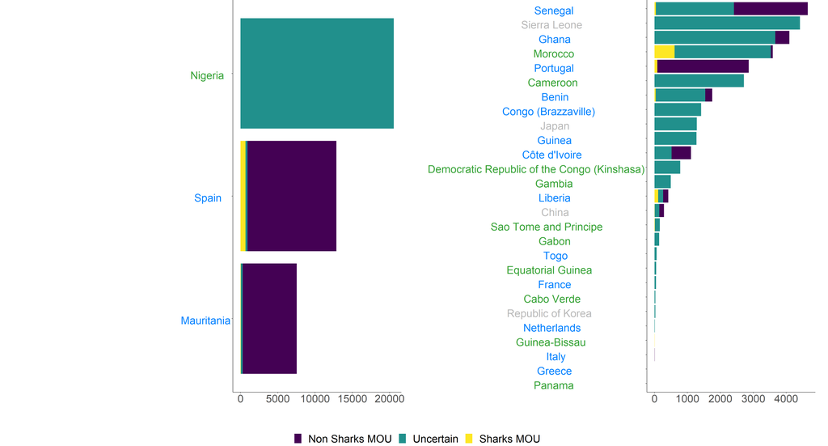

Area 34

| Country | Sharks MOU Status | CMS Status | Sharks MOU | Non Sharks MOU | Uncertain | Angelsharks, sand devils nei | Dogfish sharks nei | Guitarfishes, etc. nei | Hammerhead sharks, etc. nei | Rays, stingrays, mantas nei | Requiem sharks nei | Sharks, rays, skates, etc. nei | Yearly Average Total |
| --- | --- | --- | --- | --- | --- | --- | --- | --- | --- | --- | --- | --- | --- |
| Nigeria | Range State | Party | - | - | 20550.97 | - | - | - | - | 6636.62 | - | 13914.35 | 20550.97 |
| Spain | MOU Signatory | Party | 681.71 | 11902.62 | 268.05 | - | 1.08 | - | - | 74.47 | 122.30 | 70.20 | 12852.38 |
| Mauritania | MOU Signatory | Party | 55.00 | 7256.39 | 240.20 | - | - | - | 21.80 | 196.20 | - | 22.20 | 7551.59 |
| Senegal | MOU Signatory | Party | 39.80 | 2241.09 | 2370.65 | - | 4.40 | 720.00 | 796.11 | 721.54 | - | 128.60 | 4651.54 |
| Sierra Leone | Range State | Non-Party | - | - | 4415.00 | - | - | - | - | 1075.00 | - | 3340.00 | 4415.00 |
| Ghana | MOU Signatory | Party | - | 428.20 | 3666.46 | - | - | - | - | 1051.06 | - | 2615.40 | 4094.66 |
| Morocco | Range State | Party | 611.54 | 63.80 | 2917.90 | - | - | - | - | 1990.16 | - | 927.74 | 3593.24 |
| Portugal | MOU Signatory | Party | 87.00 | 2772.20 | - | - | - | - | - | - | - | - | 2859.20 |
| Cameroon | Range State | Party | - | - | 2713.42 | 264.60 | - | - | - | 2345.45 | - | 103.37 | 2713.42 |
| Benin | MOU Signatory | Party | 37.70 | 214.08 | 1503.80 | - | - | 136.00 | 682.80 | 90.60 | 416.20 | 178.20 | 1755.58 |
| Congo (Brazzaville) | MOU Signatory | Party | - | - | 1414.80 | - | - | - | 489.00 | 403.00 | 522.80 | - | 1414.80 |
| Japan | Range State | Non-Party | - | - | 1282.60 | - | - | - | - | - | - | 1282.60 | 1282.60 |
| Guinea | MOU Signatory | Party | - | - | 1273.40 | - | - | - | - | 286.00 | - | 987.40 | 1273.40 |
| Côte d’Ivoire | MOU Signatory | Party | - | 588.00 | 520.80 | - | - | 182.60 | 12.60 | 49.60 | 7.80 | 268.20 | 1108.80 |
| Democratic Republic of the Congo (Kinshasa) | Range State | Party | - | - | 779.80 | - | - | - | - | 240.20 | - | 539.60 | 779.80 |
| Gambia | Range State | Party | - | - | 495.39 | - | - | - | - | - | - | 495.39 | 495.39 |
| Liberia | MOU Signatory | Party | 112.60 | 154.74 | 149.56 | - | - | 21.00 | 50.40 | 62.96 | - | 15.20 | 416.90 |
| China | Range State | Non-Party | 4.00 | 142.80 | 143.20 | - | - | - | - | - | - | 143.20 | 290.00 |
| Sao Tome and Principe | Range State | Party | 9.11 | - | 151.43 | - | - | - | - | - | - | 151.43 | 160.54 |
| Gabon | Range State | Party | - | - | 143.00 | - | - | - | - | 139.00 | - | 4.00 | 143.00 |
| Togo | MOU Signatory | Party | - | - | 68.80 | - | - | - | 32.00 | 23.40 | - | 13.40 | 68.80 |
| Equatorial Guinea | Range State | Party | - | - | 50.00 | - | - | - | - | 34.60 | - | 15.40 | 50.00 |
| France | MOU Signatory | Party | - | - | 44.40 | - | - | - | - | 43.80 | - | 0.60 | 44.40 |
| Cabo Verde | Range State | Party | - | - | 28.60 | - | - | - | - | - | - | 28.60 | 28.60 |
| Republic of Korea | Range State | Non-Party | - | - | 25.60 | - | - | - | - | 22.40 | - | 3.20 | 25.60 |
| Netherlands | MOU Signatory | Party | - | 0.40 | 9.40 | - | - | - | - | - | - | 9.40 | 9.80 |
| Guinea-Bissau | Range State | Party | 5.00 | - | - | - | - | - | - | - | - | - | 5.00 |
| Italy | MOU Signatory | Party | - | 3.60 | 0.60 | - | - | - | - | 0.40 | - | 0.20 | 4.20 |
| Greece | MOU Signatory | Party | - | 2.20 | - | - | - | - | - | - | - | - | 2.20 |
| Panama | Range State | Party | - | 0.20 | - | - | - | - | - | - | - | - | 0.20 |

## Area 37 - Mediterranean and Black Sea

$~$

$~$

Area 37 - Mediterranean and Black Sea

$~$

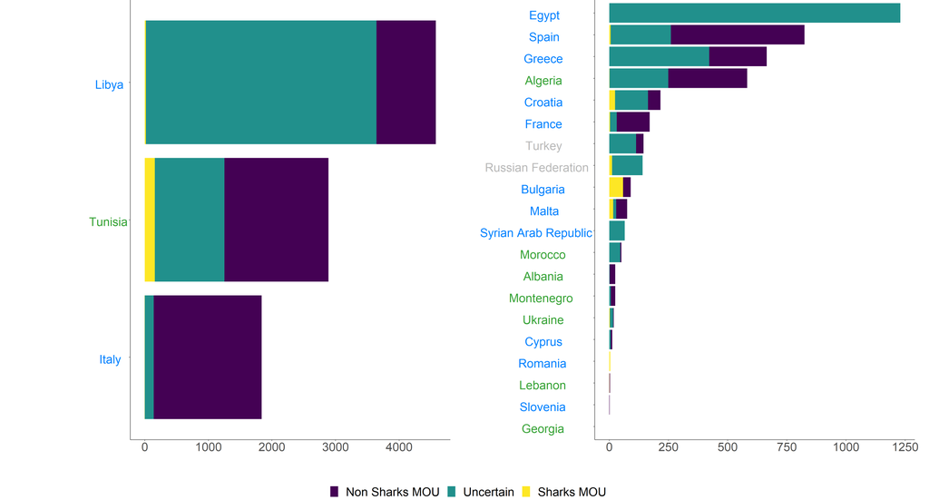

Area 37

| Country | Sharks MOU Status | CMS Status | Sharks MOU | Non Sharks MOU | Uncertain | Angelsharks, sand devils nei | Dogfish sharks nei | Dogfish sharks, etc. nei | Guitarfishes, etc. nei | Hammerhead sharks, etc. nei | Rays, stingrays, mantas nei | Requiem sharks nei | Sharks, rays, skates, etc. nei | Yearly Average Total |
| --- | --- | --- | --- | --- | --- | --- | --- | --- | --- | --- | --- | --- | --- | --- |
| Libya | MOU Signatory | Party | 18.00 | 932.20 | 3625.20 | - | 3560.00 | - | 65.20 | - | - | - | - | 4575.40 |
| Tunisia | Range State | Party | 160.00 | 1637.60 | 1091.60 | - | - | - | - | - | 1091.60 | - | - | 2889.20 |
| Italy | MOU Signatory | Party | 2.00 | 1696.40 | 138.60 | - | 71.60 | - | - | - | 25.20 | - | 41.80 | 1837.00 |
| Egypt | MOU Signatory | Party | - | - | 1229.00 | - | - | - | - | - | - | - | 1229.00 | 1229.00 |
| Spain | MOU Signatory | Party | 5.49 | 563.99 | 255.15 | 0.01 | 17.07 | - | - | - | 222.07 | 0.33 | 15.66 | 824.63 |
| Greece | MOU Signatory | Party | - | 242.80 | 422.00 | - | 93.40 | - | - | - | 328.60 | - | - | 664.80 |
| Algeria | Range State | Party | 1.32 | 333.86 | 247.68 | - | 5.50 | - | - | - | 184.64 | - | 57.54 | 582.85 |
| Croatia | MOU Signatory | Party | 24.60 | 52.40 | 139.20 | - | 45.00 | - | - | - | 94.20 | - | - | 216.20 |
| France | MOU Signatory | Party | 3.20 | 138.80 | 28.80 | - | 0.60 | - | - | - | 27.20 | - | 1.00 | 170.80 |
| Turkey | Range State | Non-Party | - | 31.40 | 113.00 | 1.00 | - | - | - | - | 112.00 | - | - | 144.40 |
| Russian Federation | Range State | Non-Party | 11.80 | - | 129.20 | - | - | - | - | - | 80.20 | - | 49.00 | 141.00 |
| Bulgaria | MOU Signatory | Party | 58.60 | 32.20 | - | - | - | - | - | - | - | - | - | 90.80 |
| Malta | MOU Signatory | Party | 16.51 | 45.96 | 12.80 | - | 1.00 | - | - | - | 11.40 | - | 0.40 | 75.27 |
| Syrian Arab Republic | MOU Signatory | Party | - | - | 65.40 | - | - | - | - | - | 25.40 | - | 40.00 | 65.40 |
| Morocco | Range State | Party | - | 4.80 | 46.78 | - | - | - | - | - | 43.18 | - | 3.60 | 51.58 |
| Albania | Range State | Party | - | 24.20 | 1.40 | 1.40 | - | - | - | - | - | - | - | 25.60 |
| Montenegro | Range State | Party | - | 18.60 | 6.60 | - | - | - | - | - | 6.20 | - | 0.40 | 25.20 |
| Ukraine | Range State | Party | 2.59 | 2.00 | 14.34 | - | - | - | - | - | 14.34 | - | - | 18.93 |
| Cyprus | MOU Signatory | Party | - | 6.20 | 6.40 | - | 0.40 | - | - | - | 5.40 | - | 0.60 | 12.60 |
| Romania | MOU Signatory | Party | 3.80 | 0.20 | - | - | - | - | - | - | - | - | - | 4.00 |
| Lebanon | Range State | Party | 0.60 | 2.40 | - | - | - | - | - | - | - | - | - | 3.00 |
| Slovenia | MOU Signatory | Party | - | 1.80 | 0.20 | - | - | - | - | - | 0.20 | - | - | 2.00 |
| Georgia | Range State | Party | 0.20 | - | 0.21 | - | - | - | - | - | - | - | 0.21 | 0.41 |

## Area 41 - Atlantic, Southwest

$~$

$~$

Area 41 - Atlantic, Southwest

$~$

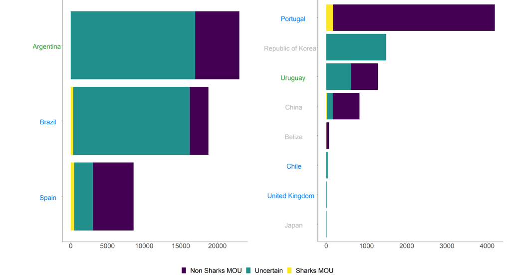

Area 41

| Country | Sharks MOU Status | CMS Status | Sharks MOU | Non Sharks MOU | Uncertain | Rays, stingrays, mantas nei | Sharks, rays, skates, etc. nei | Various sharks nei | Yearly Average Total |
| --- | --- | --- | --- | --- | --- | --- | --- | --- | --- |
| Argentina | Range State | Party | 0.40 | 6006.00 | 16968.40 | 16449.20 | - | 519.20 | 22974.80 |
| Brazil | MOU Signatory | Party | 342.60 | 2545.20 | 15880.00 | 6080.00 | 9800.00 | - | 18767.80 |
| Spain | MOU Signatory | Party | 462.15 | 5522.71 | 2586.70 | 2577.44 | 9.27 | - | 8571.56 |
| Portugal | MOU Signatory | Party | 164.80 | 4025.60 | - | - | - | - | 4190.40 |
| Republic of Korea | Range State | Non-Party | 1.02 | 9.88 | 1479.60 | 1479.60 | - | - | 1490.50 |
| Uruguay | Range State | Party | - | 669.80 | 616.20 | 598.60 | 17.60 | - | 1286.00 |
| China | Range State | Non-Party | 20.40 | 663.40 | 142.40 | - | 142.40 | - | 826.20 |
| Belize | Range State | Non-Party | 4.60 | 64.20 | - | - | - | - | 68.80 |
| Chile | MOU Signatory | Party | - | - | 38.60 | - | 38.60 | - | 38.60 |
| United Kingdom | MOU Signatory | Party | - | - | 14.20 | 14.20 | - | - | 14.20 |
| Japan | Range State | Non-Party | - | - | 10.00 | - | 10.00 | - | 10.00 |

## Area 47 - Atlantic, Southeast

$~$

$~$

Area 47 - Atlantic, Southeast

$~$

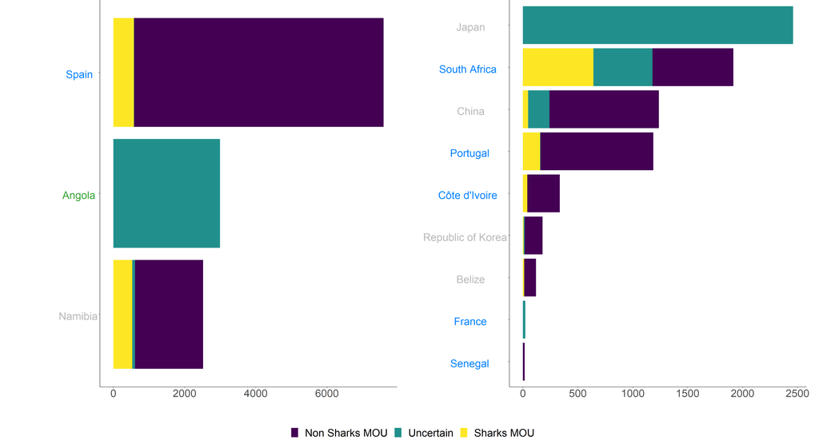

Area 47

| Country | Sharks MOU Status | CMS Status | Sharks MOU | Non Sharks MOU | Uncertain | Rays, stingrays, mantas nei | Sharks, rays, skates, etc. nei | Yearly Average Total |
| --- | --- | --- | --- | --- | --- | --- | --- | --- |
| Spain | MOU Signatory | Party | 576.08 | 7007.59 | 6.00 | 5.80 | 0.20 | 7589.66 |
| Angola | Range State | Party | - | - | 2997.60 | 1765.20 | 1232.40 | 2997.60 |
| Namibia | Range State | Non-Party | 531.60 | 1911.80 | 77.20 | - | 77.20 | 2520.60 |
| Japan | Range State | Non-Party | - | - | 2458.80 | - | 2458.80 | 2458.80 |
| South Africa | MOU Signatory | Party | 642.56 | 737.06 | 536.62 | 63.60 | 473.02 | 1916.25 |
| China | Range State | Non-Party | 48.40 | 995.60 | 193.40 | - | 193.40 | 1237.40 |
| Portugal | MOU Signatory | Party | 157.20 | 1027.60 | 3.00 | - | 3.00 | 1187.80 |
| Côte d’Ivoire | MOU Signatory | Party | 40.20 | 296.40 | - | - | - | 336.60 |
| Republic of Korea | Range State | Non-Party | 7.96 | 162.35 | 8.80 | - | 8.80 | 179.11 |
| Belize | Range State | Non-Party | 12.40 | 107.60 | - | - | - | 120.00 |
| France | MOU Signatory | Party | - | - | 22.40 | 18.00 | 4.40 | 22.40 |
| Senegal | MOU Signatory | Party | - | 16.63 | - | - | - | 16.63 |

## Area 51 - Indian Ocean, Western

$~$

$~$

Area 51 - Indian Ocean, Western

$~$

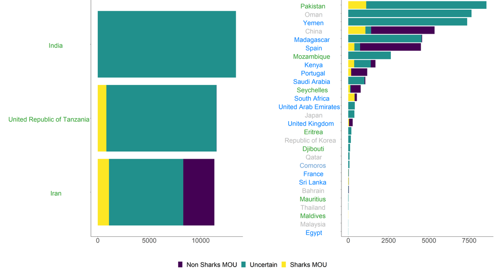

Area 51

| Country | Sharks MOU Status | CMS Status | Sharks MOU | Non Sharks MOU | Uncertain | Dogfish sharks nei | Guitarfishes, etc. nei | Hammerhead sharks, etc. nei | Rays, stingrays, mantas nei | Requiem sharks nei | Sharks, rays, skates, etc. nei | Various sharks nei | Yearly Average Total |
| --- | --- | --- | --- | --- | --- | --- | --- | --- | --- | --- | --- | --- | --- |
| India | Range State | Party | - | - | 13432.09 | - | - | - | - | - | 13432.09 | - | 13432.09 |
| United Republic of Tanzania | Range State | Party | 839.20 | 12.40 | 10695.60 | - | - | - | 2508.80 | - | 8186.80 | - | 11547.20 |
| Iran | Range State | Party | 1092.20 | 3027.00 | 7212.00 | - | - | - | 6663.00 | - | - | 549.00 | 11331.20 |
| Pakistan | Range State | Party | 1110.60 | - | 7457.80 | - | 1425.00 | - | 23.00 | 5797.20 | - | 212.60 | 8568.40 |
| Oman | Range State | Non-Party | - | - | 7642.00 | - | - | - | 1033.80 | - | 6608.20 | - | 7642.00 |
| Yemen | MOU Signatory | Party | - | - | 7372.20 | - | - | - | - | - | 7372.20 | - | 7372.20 |
| China | Range State | Non-Party | 1061.40 | 3929.80 | 358.00 | - | - | 8.60 | - | - | 349.40 | - | 5349.20 |
| Madagascar | MOU Signatory | Party | - | 28.20 | 4549.00 | - | - | - | - | - | 4549.00 | - | 4577.20 |
| Spain | MOU Signatory | Party | 377.95 | 3771.73 | 354.32 | 39.69 | - | - | 9.63 | 1.40 | 303.60 | - | 4504.00 |
| Mozambique | Range State | Party | 0.40 | 3.00 | 2635.20 | - | - | 498.80 | - | 108.60 | 2027.80 | - | 2638.60 |
| Kenya | MOU Signatory | Party | 363.80 | 296.40 | 1025.80 | - | - | 12.00 | 283.40 | 291.20 | 439.20 | - | 1686.00 |
| Portugal | MOU Signatory | Party | 175.40 | 1001.60 | - | - | - | - | - | - | - | - | 1177.00 |
| Saudi Arabia | MOU Signatory | Party | - | 52.80 | 1004.20 | - | - | - | - | - | 1004.20 | - | 1057.00 |
| Seychelles | Range State | Party | 104.00 | 618.40 | 47.00 | - | - | - | - | - | 47.00 | - | 769.40 |
| South Africa | MOU Signatory | Party | 389.00 | 136.80 | 8.40 | - | - | - | - | 8.40 | - | - | 534.20 |
| United Arab Emirates | MOU Signatory | Party | - | - | 400.00 | - | - | - | - | - | 400.00 | - | 400.00 |
| Japan | Range State | Non-Party | - | - | 376.40 | - | - | - | - | - | 376.40 | - | 376.40 |
| United Kingdom | MOU Signatory | Party | 46.20 | 222.60 | - | - | - | - | - | - | - | - | 268.80 |
| Eritrea | Range State | Party | - | - | 192.60 | - | - | - | - | 192.60 | - | - | 192.60 |
| Republic of Korea | Range State | Non-Party | - | - | 159.60 | - | - | - | - | - | 159.60 | - | 159.60 |
| Djibouti | Range State | Party | - | - | 112.41 | - | - | - | 0.02 | 28.39 | 84.00 | - | 112.41 |
| Qatar | Range State | Non-Party | - | - | 80.40 | - | - | - | - | 80.40 | - | - | 80.40 |
| Comoros | MOU Signatory | Non-Party | - | - | 74.60 | - | - | - | - | - | 74.60 | - | 74.60 |
| France | MOU Signatory | Party | 5.40 | 3.60 | 26.00 | - | - | - | - | - | 26.00 | - | 35.00 |
| Sri Lanka | MOU Signatory | Party | 25.08 | 6.82 | 1.98 | - | - | - | 1.46 | - | 0.52 | - | 33.88 |
| Bahrain | Range State | Non-Party | - | 14.00 | 18.00 | - | - | - | - | 18.00 | - | - | 32.00 |
| Mauritius | Range State | Party | - | - | 15.80 | - | - | - | - | - | 15.80 | - | 15.80 |
| Thailand | Range State | Non-Party | - | - | 11.60 | - | - | - | - | - | 11.60 | - | 11.60 |
| Maldives | Range State | Party | 1.00 | - | 2.00 | - | - | - | - | - | 2.00 | - | 3.00 |
| Malaysia | Range State | Non-Party | - | - | 1.00 | - | - | - | - | - | - | 1.00 | 1.00 |
| Egypt | MOU Signatory | Party | - | - | 0.80 | - | - | - | - | - | 0.80 | - | 0.80 |

## Area 57 - Indian Ocean, Eastern

$~$

$~$

Area 57 - Indian Ocean, Eastern

$~$

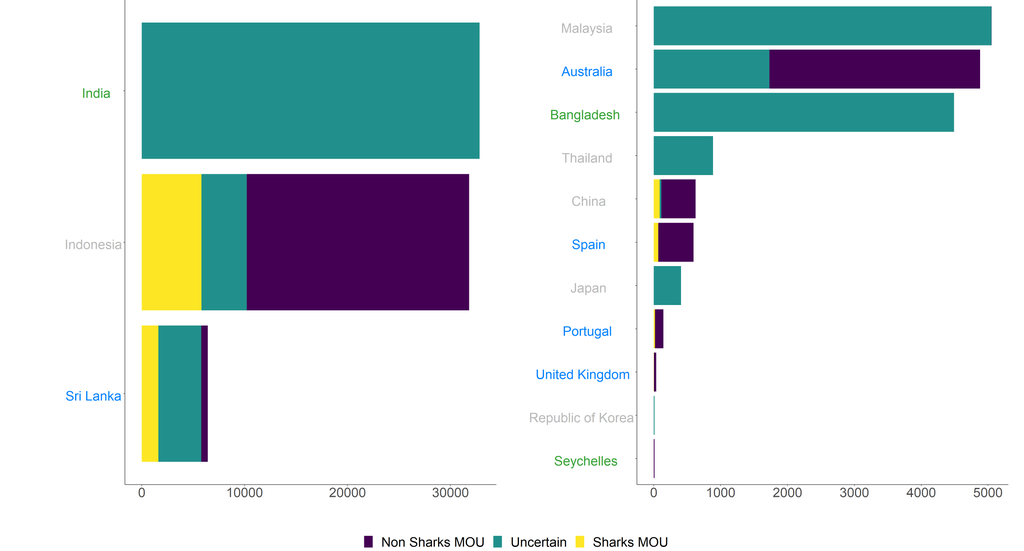

Area 57

| Country | Sharks MOU Status | CMS Status | Sharks MOU | Non Sharks MOU | Uncertain | Angelsharks, sand devils nei | Guitarfishes, etc. nei | Hammerhead sharks, etc. nei | Rays, stingrays, mantas nei | Requiem sharks nei | Sharks, rays, skates, etc. nei | Yearly Average Total |
| --- | --- | --- | --- | --- | --- | --- | --- | --- | --- | --- | --- | --- |
| India | Range State | Party | - | - | 32828.09 | - | - | - | - | - | 32828.09 | 32828.09 |
| Indonesia | Range State | Non-Party | 5803.40 | 21621.70 | 4402.20 | - | 226.80 | 1538.60 | 2600.60 | 36.20 | - | 31827.30 |
| Sri Lanka | MOU Signatory | Party | 1626.32 | 641.14 | 4161.18 | - | - | 66.26 | - | - | 4094.92 | 6428.64 |
| Malaysia | Range State | Non-Party | 1.20 | 0.40 | 5051.04 | - | - | - | 3833.10 | - | 1217.94 | 5052.64 |
| Australia | MOU Signatory | Party | 0.10 | 3150.35 | 1732.17 | 78.40 | - | - | 99.95 | - | 1553.82 | 4882.62 |
| Bangladesh | Range State | Party | - | - | 4491.60 | - | - | - | - | - | 4491.60 | 4491.60 |
| Thailand | Range State | Non-Party | - | - | 887.00 | - | - | - | 734.00 | - | 153.00 | 887.00 |
| China | Range State | Non-Party | 89.00 | 512.80 | 24.40 | - | - | 0.20 | - | - | 24.20 | 626.20 |
| Spain | MOU Signatory | Party | 66.40 | 528.60 | 1.01 | - | - | - | - | - | 1.01 | 596.01 |
| Japan | Range State | Non-Party | - | - | 407.80 | - | - | - | - | - | 407.80 | 407.80 |
| Portugal | MOU Signatory | Party | 19.60 | 125.80 | - | - | - | - | - | - | - | 145.40 |
| United Kingdom | MOU Signatory | Party | 4.00 | 34.60 | - | - | - | - | - | - | - | 38.60 |
| Republic of Korea | Range State | Non-Party | - | - | 13.80 | - | - | - | - | - | 13.80 | 13.80 |
| Seychelles | Range State | Party | - | 11.00 | 1.20 | - | - | - | - | - | 1.20 | 12.20 |

## Area 61 - Pacific, Northwest

$~$

$~$

Area 61 - Pacific, Northwest

$~$

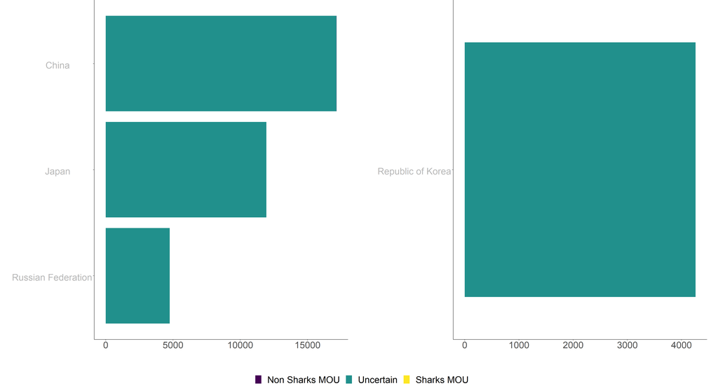

Area 61

| Country | Sharks MOU Status | CMS Status | Sharks MOU | Non Sharks MOU | Uncertain | Rays, stingrays, mantas nei | Sharks, rays, skates, etc. nei | Yearly Average Total |
| --- | --- | --- | --- | --- | --- | --- | --- | --- |
| China | Range State | Non-Party | 0.20 | 2.20 | 17149.80 | 184.60 | 16965.20 | 17152.20 |
| Japan | Range State | Non-Party | - | - | 11938.20 | - | 11938.20 | 11938.20 |
| Russian Federation | Range State | Non-Party | - | - | 4760.60 | 4760.60 | - | 4760.60 |
| Republic of Korea | Range State | Non-Party | - | - | 4258.00 | 4048.40 | 209.60 | 4258.00 |

## Area 67 - Pacific, Northeast

$~$

$~$

Area 67 - Pacific, Northeast

$~$

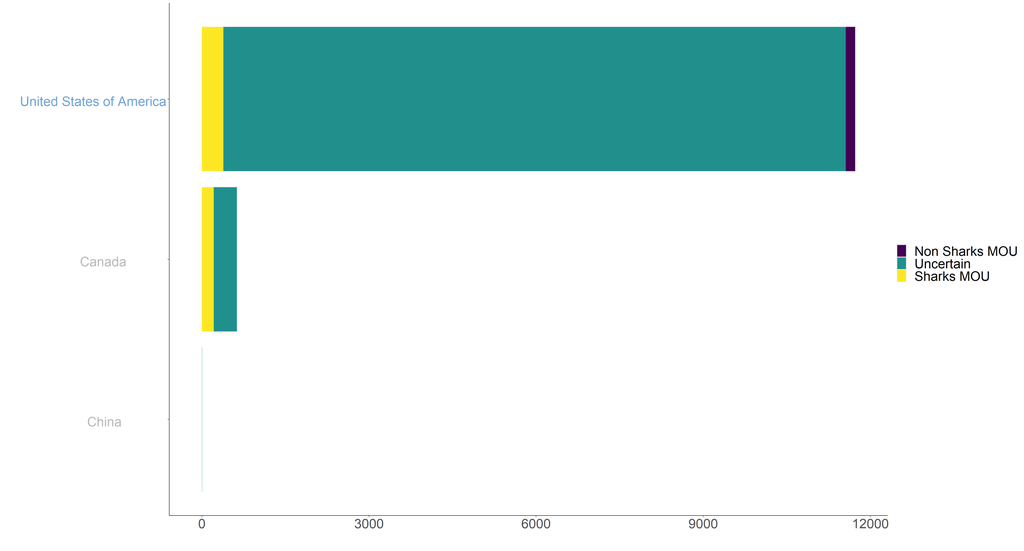

Area 67

| Country | Sharks MOU Status | CMS Status | Sharks MOU | Non Sharks MOU | Uncertain | Rays, stingrays, mantas nei | Sharks, rays, skates, etc. nei | Yearly Average Total |
| --- | --- | --- | --- | --- | --- | --- | --- | --- |
| United States of America | MOU Signatory | Non-Party | 386.00 | 168.60 | 11173.60 | 11115.60 | 58.00 | 11728.20 |
| Canada | Range State | Non-Party | 213.80 | - | 414.80 | 414.80 | - | 628.60 |
| China | Range State | Non-Party | - | - | 5.40 | - | 5.40 | 5.40 |

## Area 71 - Pacific, Western Central

$~$

$~$

Area 71 - Pacific, Western Central

$~$

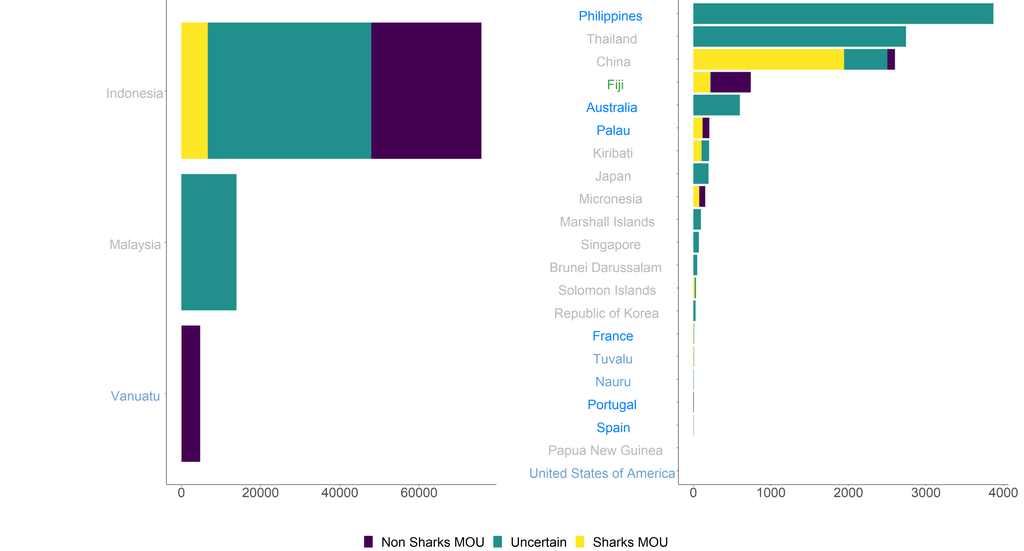

Area 71

| Country | Sharks MOU Status | CMS Status | Sharks MOU | Non Sharks MOU | Uncertain | Dogfish sharks nei | Guitarfishes, etc. nei | Hammerhead sharks nei | Hammerhead sharks, etc. nei | Rays, stingrays, mantas nei | Requiem sharks nei | Sharks, rays, skates, etc. nei | Yearly Average Total |
| --- | --- | --- | --- | --- | --- | --- | --- | --- | --- | --- | --- | --- | --- |
| Indonesia | Range State | Non-Party | 6685.86 | 27764.38 | 41274.40 | 3437.40 | 444.00 | - | 42.80 | 28167.00 | 9183.20 | - | 75724.64 |
| Malaysia | Range State | Non-Party | - | - | 13917.14 | - | - | - | - | 8583.57 | - | 5333.58 | 13917.14 |
| Vanuatu | MOU Signatory | Non-Party | 67.80 | 4683.60 | 0.56 | - | - | - | - | - | - | 0.56 | 4751.96 |
| Philippines | MOU Signatory | Party | - | - | 3870.60 | - | - | - | - | 1899.40 | - | 1971.20 | 3870.60 |
| Thailand | Range State | Non-Party | - | - | 2745.00 | - | - | - | - | 2143.40 | - | 601.60 | 2745.00 |
| China | Range State | Non-Party | 1944.80 | 98.40 | 557.80 | - | - | - | 270.80 | - | - | 287.00 | 2601.00 |
| Fiji | Range State | Party | 217.40 | 512.40 | 11.40 | - | - | - | 11.40 | - | - | - | 741.20 |
| Australia | MOU Signatory | Party | - | - | 601.15 | - | - | - | - | - | - | 601.15 | 601.15 |
| Palau | MOU Signatory | Party | 118.82 | 86.70 | 0.63 | - | - | 0.63 | - | - | - | - | 206.15 |
| Kiribati | Range State | Non-Party | 105.40 | - | 98.60 | - | - | - | - | - | - | 98.60 | 204.00 |
| Japan | Range State | Non-Party | - | - | 196.20 | - | - | - | - | - | - | 196.20 | 196.20 |
| Micronesia | Range State | Non-Party | 78.40 | 75.40 | - | - | - | - | - | - | - | - | 153.80 |
| Marshall Islands | Range State | Non-Party | - | - | 97.40 | - | - | - | - | - | - | 97.40 | 97.40 |
| Singapore | Range State | Non-Party | - | - | 72.00 | - | - | - | - | 61.41 | - | 10.59 | 72.00 |
| Brunei Darussalam | Range State | Non-Party | - | - | 51.28 | - | - | - | - | 51.28 | - | - | 51.28 |
| Solomon Islands | Range State | Non-Party | 19.60 | - | 14.80 | - | - | - | - | - | - | 14.80 | 34.40 |
| Republic of Korea | Range State | Non-Party | - | - | 30.00 | - | - | - | - | - | - | 30.00 | 30.00 |
| France | MOU Signatory | Party | 6.80 | - | 4.00 | - | - | - | - | - | - | 4.00 | 10.80 |
| Tuvalu | MOU Signatory | Non-Party | 5.80 | 2.20 | - | - | - | - | - | - | - | - | 8.00 |
| Nauru | MOU Signatory | Non-Party | - | - | 5.40 | - | - | - | - | - | - | 5.40 | 5.40 |
| Portugal | MOU Signatory | Party | 0.80 | 4.00 | - | - | - | - | - | - | - | - | 4.80 |
| Spain | MOU Signatory | Party | 0.60 | 2.20 | - | - | - | - | - | - | - | - | 2.80 |
| Papua New Guinea | Range State | Non-Party | 1.20 | - | - | - | - | - | - | - | - | - | 1.20 |
| United States of America | MOU Signatory | Non-Party | 0.60 | - | - | - | - | - | - | - | - | - | 0.60 |

## Area 77 - Pacific, Eastern Central

$~$

$~$

Area 77 - Pacific, Eastern Central

$~$

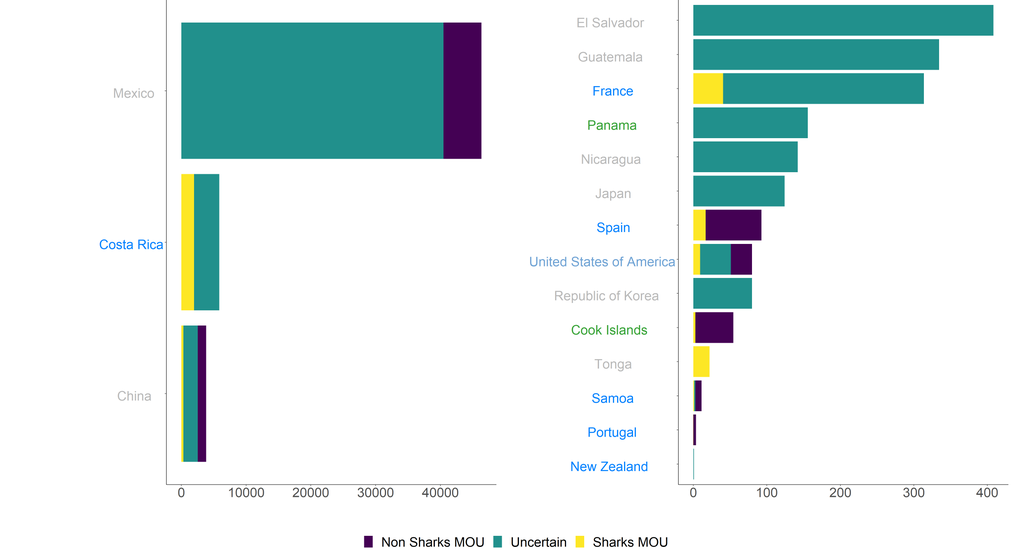

Area 77

| Country | Sharks MOU Status | CMS Status | Sharks MOU | Non Sharks MOU | Uncertain | Hammerhead sharks, etc. nei | Rays, stingrays, mantas nei | Requiem sharks nei | Sharks, rays, skates, etc. nei | Yearly Average Total |
| --- | --- | --- | --- | --- | --- | --- | --- | --- | --- | --- |
| Mexico | Range State | Non-Party | - | 5844.40 | 40483.00 | 3569.40 | 10192.80 | 4755.20 | 21965.60 | 46327.40 |
| Costa Rica | MOU Signatory | Party | 1958.20 | - | 3898.00 | - | - | - | 3898.00 | 5856.20 |
| China | Range State | Non-Party | 331.20 | 1290.00 | 2207.40 | - | - | - | 2207.40 | 3828.60 |
| El Salvador | Range State | Non-Party | - | - | 408.20 | - | - | - | 408.20 | 408.20 |
| Guatemala | Range State | Non-Party | - | - | 334.20 | - | - | - | 334.20 | 334.20 |
| France | MOU Signatory | Party | 40.40 | - | 273.40 | - | - | 267.00 | 6.40 | 313.80 |
| Panama | Range State | Party | - | - | 155.80 | - | - | - | 155.80 | 155.80 |
| Nicaragua | Range State | Non-Party | - | - | 142.22 | - | 115.82 | - | 26.40 | 142.22 |
| Japan | Range State | Non-Party | - | - | 124.20 | - | - | - | 124.20 | 124.20 |
| Spain | MOU Signatory | Party | 16.70 | 76.02 | - | - | - | - | - | 92.71 |
| United States of America | MOU Signatory | Non-Party | 9.20 | 28.80 | 42.00 | - | - | - | 42.00 | 80.00 |
| Republic of Korea | Range State | Non-Party | - | - | 79.80 | - | - | - | 79.80 | 79.80 |
| Cook Islands | Range State | Party | 2.80 | 51.60 | - | - | - | - | - | 54.40 |
| Tonga | Range State | Non-Party | 22.20 | - | - | - | - | - | - | 22.20 |
| Samoa | MOU Signatory | Party | 1.30 | 8.40 | 1.60 | - | - | - | 1.60 | 11.30 |
| Portugal | MOU Signatory | Party | 0.20 | 3.60 | - | - | - | - | - | 3.80 |
| New Zealand | MOU Signatory | Party | - | - | 1.00 | - | - | - | 1.00 | 1.00 |

## Area 81 - Pacific, Southwest

$~$

$~$

Area 81 - Pacific, Southwest

$~$

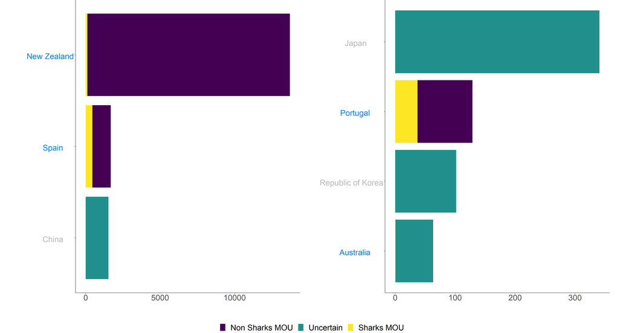

Area 81

| Country | Sharks MOU Status | CMS Status | Sharks MOU | Non Sharks MOU | Uncertain | Rays, stingrays, mantas nei | Sharks, rays, skates, etc. nei | Yearly Average Total |
| --- | --- | --- | --- | --- | --- | --- | --- | --- |
| New Zealand | MOU Signatory | Party | 112.40 | 13586.40 | 13.00 | 10.40 | 2.60 | 13711.80 |
| Spain | MOU Signatory | Party | 447.08 | 1237.50 | 2.40 | - | 2.40 | 1686.98 |
| China | Range State | Non-Party | 1.40 | 12.20 | 1513.00 | - | 1513.00 | 1526.60 |
| Japan | Range State | Non-Party | - | - | 340.60 | - | 340.60 | 340.60 |
| Portugal | MOU Signatory | Party | 37.20 | 91.60 | - | - | - | 128.80 |
| Republic of Korea | Range State | Non-Party | - | - | 101.80 | 0.20 | 101.60 | 101.80 |
| Australia | MOU Signatory | Party | 0.40 | 0.40 | 62.23 | 7.20 | 55.03 | 63.03 |

## Area 87 - Pacific, Southeast

$~$

$~$

Area 87 - Pacific, Southeast

$~$

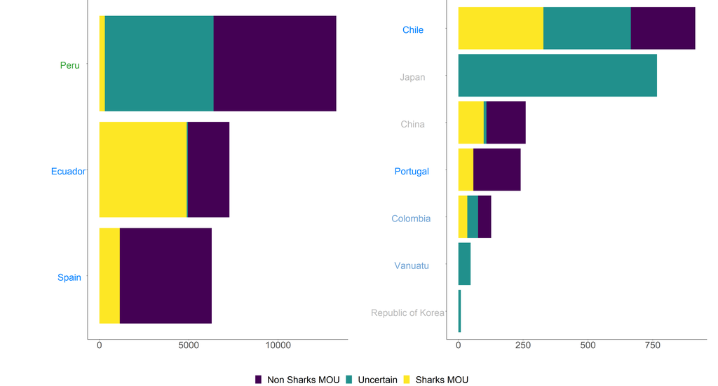

Area 87

| Country | Sharks MOU Status | CMS Status | Sharks MOU | Non Sharks MOU | Uncertain | Hammerhead sharks, etc. nei | Rays, stingrays, mantas nei | Requiem sharks nei | Sharks, rays, skates, etc. nei | Yearly Average Total |
| --- | --- | --- | --- | --- | --- | --- | --- | --- | --- | --- |
| Peru | Range State | Party | 305.02 | 6861.82 | 6086.20 | - | 1350.80 | - | 4735.40 | 13253.04 |
| Ecuador | MOU Signatory | Party | 4885.74 | 2326.51 | 65.98 | - | 38.00 | 5.03 | 22.95 | 7278.24 |
| Spain | MOU Signatory | Party | 1139.81 | 5142.73 | 0.94 | - | - | - | 0.94 | 6283.48 |
| Chile | MOU Signatory | Party | 328.00 | 248.40 | 337.80 | - | 337.80 | - | - | 914.20 |
| Japan | Range State | Non-Party | - | - | 767.00 | - | - | - | 767.00 | 767.00 |
| China | Range State | Non-Party | 98.00 | 151.60 | 10.40 | - | - | - | 10.40 | 260.00 |
| Portugal | MOU Signatory | Party | 57.60 | 182.60 | - | - | - | - | - | 240.20 |
| Colombia | MOU Signatory | Non-Party | 34.36 | 50.27 | 41.89 | 7.60 | 33.49 | - | 0.80 | 126.52 |
| Vanuatu | MOU Signatory | Non-Party | - | - | 47.40 | - | - | - | 47.40 | 47.40 |
| Republic of Korea | Range State | Non-Party | - | - | 9.40 | - | - | - | 9.40 | 9.40 |

## Area SO - Antarctic

$~$

$~$

Area SO - Antartic

$~$

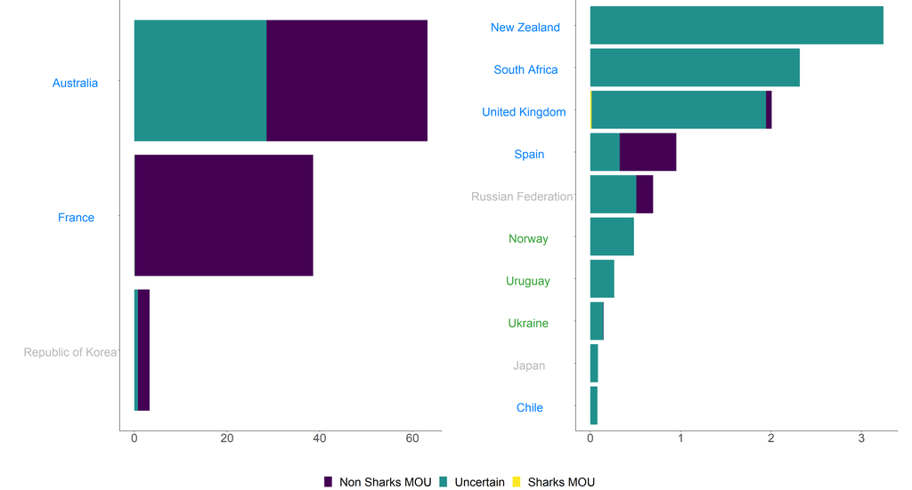

Area SO

| Country | Sharks MOU Status | CMS Status | Sharks MOU | Non Sharks MOU | Uncertain | Rays, stingrays, mantas nei | Yearly Average Total |
| --- | --- | --- | --- | --- | --- | --- | --- |
| Australia | MOU Signatory | Party | 0.01 | 34.71 | 28.50 | 28.50 | 63.22 |
| France | MOU Signatory | Party | 0.05 | 38.42 | 0.08 | 0.08 | 38.56 |
| Republic of Korea | Range State | Non-Party | - | 2.54 | 0.79 | 0.79 | 3.33 |
| New Zealand | MOU Signatory | Party | - | - | 3.24 | 3.24 | 3.24 |
| South Africa | MOU Signatory | Party | - | - | 2.32 | 2.32 | 2.32 |
| United Kingdom | MOU Signatory | Party | 0.01 | 0.06 | 1.93 | 1.93 | 2.01 |
| Spain | MOU Signatory | Party | - | 0.63 | 0.33 | 0.33 | 0.95 |
| Russian Federation | Range State | Non-Party | - | 0.19 | 0.51 | 0.51 | 0.70 |
| Norway | Range State | Party | - | - | 0.48 | 0.48 | 0.48 |
| Uruguay | Range State | Party | - | - | 0.27 | 0.27 | 0.27 |
| Ukraine | Range State | Party | - | - | 0.14 | 0.14 | 0.15 |
| Japan | Range State | Non-Party | - | - | 0.09 | 0.09 | 0.09 |
| Chile | MOU Signatory | Party | - | - | 0.08 | 0.08 | 0.08 |